# Plot Normal Distribution

### More Probability Plots

This section describes creating probability plots in R for both didactic purposes and for data analyses.

Probability Plots for Teaching and Demonstration When I was a college professor teaching statistics, I used to have to draw normal distributions by hand. They always came out looking like bunny rabbits. What can I say?

R makes it easy to draw probability distributions and demonstrate statistical concepts. Some of the more common probability distributions available in R are given below.

distribution R name distribution R name Beta beta Lognormal lnorm Binomial binom Negative Binomial nbinom Cauchy cauchy Normal norm Chisquare chisq Poisson pois Exponential exp Student t t F f Uniform unif Gamma gamma Tukey tukey Geometric geom Weibull weib Hypergeometric hyper Wilcoxon wilcox Logistic logis  
For a comprehensive list, see Statistical Distributions on the R wiki. The functions available for each distribution follow this format:

name description dname( ) density or probability function pname( ) cumulative density function qname( ) quantile function Rname( ) random deviates For example, pnorm(0) =0.5 (the area under the standard normal curve to the left of zero). qnorm(0.9) = 1.28 (1.28 is the 90th percentile of the standard normal distribution). rnorm(100) generates 100 random deviates from a standard normal distribution.

Each function has parameters specific to that distribution. For example, rnorm(100, m=50, sd=10) generates 100 random deviates from a normal distribution with mean 50 and standard deviation 10.

You can use these functions to demonstrate various aspects of probability distributions. Two common examples are given below.

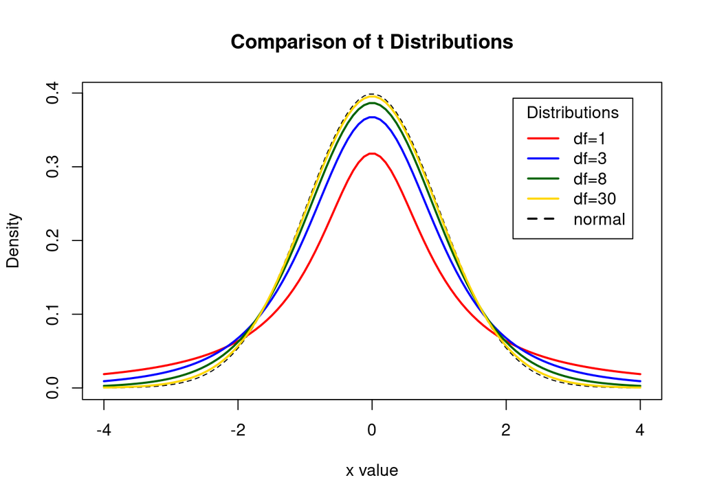

```r
# Display the Student's t distributions with various
# degrees of freedom and compare to the normal distribution

x <- seq( -4, 4, length=100 )
hx <- dnorm( x )

degf <- c( 1, 3, 8, 30 )
colors <- c( "red", "blue", "darkgreen", "gold", "black" )
labels <- c( "df=1", "df=3", "df=8", "df=30", "normal" )

plot( x, hx, type="l", lty=2, xlab="x value", ylab="Density", main="Comparison of t Distributions" )

for( i in 1:4 ) {
  lines( x, dt( x, degf[i] ), lwd=2, col=colors[i] )
}

legend( "topright", inset=.05, title="Distributions", labels, lwd=2, lty=c( 1, 1, 1, 1, 2 ), col=colors )
```

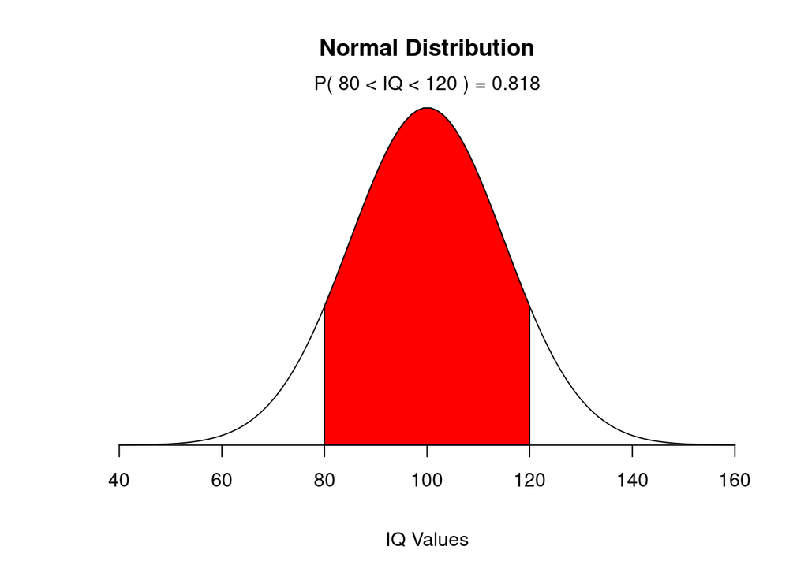

```r
# Children's IQ scores are normally distributed with a
# mean of 100 and a standard deviation of 15. What
# proportion of children are expected to have an IQ between
# 80 and 120?

mean=100; sd=15
lb=80; ub=120

x <- seq( -4, 4, length=100 ) * sd + mean
hx <- dnorm( x, mean, sd )

plot( x, hx, type="n", xlab="IQ Values", ylab="", main="Normal Distribution", axes=FALSE )

i <- x >= lb & x <= ub
lines( x, hx )
polygon( c( lb, x[i], ub ), c( 0, hx[i], 0 ), col="red" )

area <- pnorm( ub, mean, sd ) - pnorm( lb, mean, sd )
result <- paste( "P(", lb, "< IQ <", ub, ") =", signif( area, digits=3 ) )
mtext( result, 3 )

axis( 1, at=seq( 40, 160, 20 ), pos=0 )
```

### Fitting Distributions

There are several methods of fitting distributions in R. Here are some options.

You can use the qqnorm( ) function to create a Quantile-Quantile plot evaluating the fit of sample data to the normal distribution. More generally, the qqplot( ) function creates a Quantile-Quantile plot for any theoretical distribution.

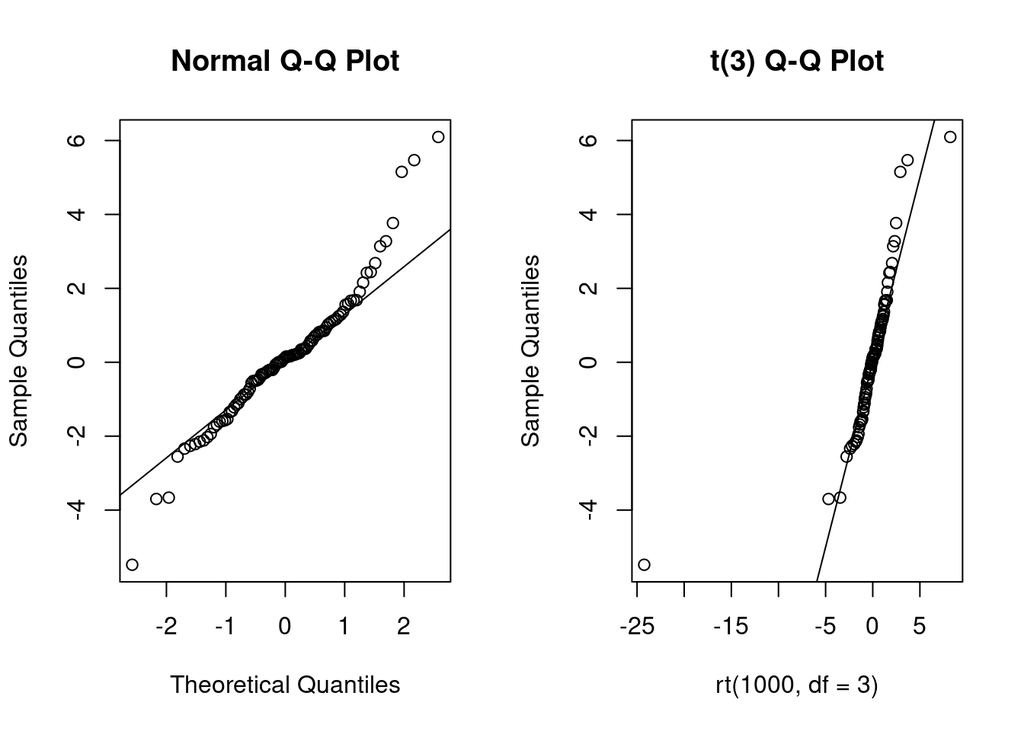

```r
# Q-Q plots
par( mfrow=c( 1, 2 ) )

# create sample data
x <- rt( 100, df=3 )

# normal fit
qqnorm( x ); qqline( x )

# t(3Df) fit
qqplot( rt( 1000, df=3 ), x, main="t(3) Q-Q Plot", ylab="Sample Quantiles" )
abline( 0, 1 )
```

The fitdistr( ) function in the MASS package provides maximum-likelihood fitting of univariate distributions. The format is fitdistr(x, densityfunction) where x is the sample data and densityfunction is one of the following: “beta”, “cauchy”, “chi-squared”, “exponential”, “f”, “gamma”, “geometric”, “log-normal”, “lognormal”, “logistic”, “negative binomial”, “normal”, “Poisson”, “t” or “weibull”.

```r
# Estimate parameters assuming log-Normal distribution

# create some sample data
x <- rlnorm( 100 )

# estimate paramters
library( MASS )
fitdistr( x, "lognormal" )
```

```
##      meanlog        sdlog
##   -0.07511337    0.98082658
##  ( 0.09808266) ( 0.06935491)
```